# Intro to DS - HW09 KNN

Izzy Illari

12 April, 2020

# Pima Dataset

## Preparation and EDA

### Question 1

**Obtain the dataset**

> In the `MASS` library, combine the two datasets `Pima.te` and `Pima.tr` back into one complete dataset, call it `pima`. (Try function `rbind()`.) How many observations are there?

```r
loadPkg(MASS)
data1 = MASS::Pima.te
data2 = MASS::Pima.tr
pima = rbind(data1, data2)
str(pima)
```

```
## 'data.frame':    532 obs. of  8 variables:
##  $ npreg: int  6 1 1 3 2 5 0 1 3 9 ...
##  $ glu  : int  148 85 89 78 197 166 118 103 126 119 ...
##  $ bp   : int  72 66 66 50 70 72 84 30 88 80 ...
##  $ skin : int  35 29 23 32 45 19 47 38 41 35 ...
##  $ bmi  : num  33.6 26.6 28.1 31 30.5 25.8 45.8 43.3 39.3 29 ...
##  $ ped  : num  0.627 0.351 0.167 0.248 0.158 0.587 0.551 0.183 0.704 0.263 ...
##  $ age  : int  50 31 21 26 53 51 31 33 27 29 ...
##  $ type : Factor w/ 2 levels "No","Yes": 2 1 1 2 2 2 2 1 1 2 ...
```

There are 532 observations of 8 variables in `pima`.

The dataset includes measurement on a population of women of Pima Indian heritage living near Phoenix, Arizona.

The women were tested for diabetes according to World Health Organization criteria. The variables in the dataset are:  
* npreg : number of pregnancies.  
* glu : plasma glucose concentration  
* bp : diastolic blood pressure (mm Hg) skin triceps skinfold thickness (mm)  
* bmi : body mass index  
* ped : diabetes pedigree function  
* age : age in years  
* type : Yes or No: diabetic by WHO criteria

### Question 2

**Summary**

> Obtain some basic summary data for pima. (You can try the `xkablesummary()` function introduced in the previous HW7 solution.)

Here is a table summarizing the staistics for each of the 8 variables in `pima`:

```r
xkablesummary(pima)
```

Table: Statistics summary.

|  | npreg | glu | bp | skin | bmi | ped | age | type |
| --- | --- | --- | --- | --- | --- | --- | --- | --- |
| Min | 0.00 | 56.0 | 24.0 | 7.0 | 18.2 | 0.085 | 21.0 | No :355 |
| Q1 | 1.00 | 98.8 | 64.0 | 22.0 | 27.9 | 0.259 | 23.0 | Yes:177 |
| Median | 2.00 | 115.0 | 72.0 | 29.0 | 32.8 | 0.416 | 28.0 | NA |
| Mean | 3.52 | 121.0 | 71.5 | 29.2 | 32.9 | 0.503 | 31.6 | NA |
| Q3 | 5.00 | 141.2 | 80.0 | 36.0 | 36.9 | 0.658 | 38.0 | NA |
| Max | 17.00 | 199.0 | 110.0 | 99.0 | 67.1 | 2.420 | 81.0 | NA |

### Question 3

**Pairs**

> Another quick EDA to perform, you can plot the `pairs()`. The plot function can handle both numerical and categorical variable type. After trying the function in the R base library, also try the modified version with `pairs.panels()`.

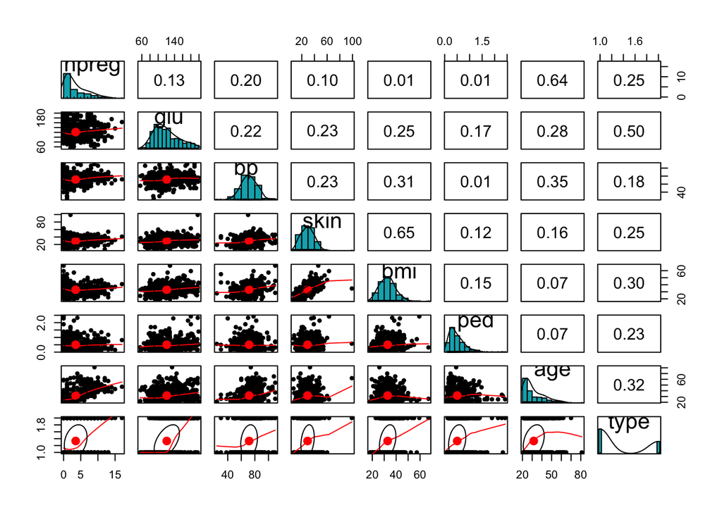

```r
loadPkg(psych)
pairs.panels(pima, #data frame
             method = "pearson", # correlation method
             hist.col = "#00AFBB", # set histogram color, can use "#22AFBB", "red",
             density = TRUE,  # show density plots
             ellipses = TRUE # show correlation ellipses
             )
```

```r
unloadPkg(psych)
```

It seems that the data is not really highly correlated with each other. If we see straight lines in the scatter plots that shows a trend of zero correlation. The most correleted variables are `npreg` and `age`, with a correlation of 0.641, and `skin` and `bmi`, with a correlation of 0.647

## KNN

### Question 4

**Train-Test split 3:1**

> In order to perform KNN analysis, we need to separate the X-variables and the y-labels. (Which should be our y-variable?) Before we separate them out, create a vector/array of 1 and 2 to create a train-test split in the ratio of 3:1. (Set a constant seed value so that we can duplicate the results.) So eventually, you will get the training Xs as a dataframe, training y-label (a vector), as well as the test sets together in four groups. Make sure the train-X and train-y are not mixed up in the ordering during the process. Same for test-X and test-y.

First we want to scale the data so KNN will operate correctly and we use all columns except the last one bc the others are numeric and last is factor. Then we will set the seed, and create the test and train data sets. These will be made using a sample fraction. We want to create 2 data sets, and by using replacement this means we can reset the random sampling across each vector and the probability gives sample the weight of the splits, 3/4 for train, 1/4 for test. We want a ratio of 3:1, which means “three times” the original, or that the odds are less than 1 in 4 (4=1+3) or less than 25%. This means our train will be 75% and our test will be 25%.

```r
loadPkg(FNN)
end <- as.integer(ncol(pima)-1)
scaledpima <- as.data.frame(scale(pima[1:end], center = TRUE, scale = TRUE))
#set seed
set.seed(1000)
#sample
pima_sample <- sample(2, nrow(scaledpima), replace=TRUE, prob=c(0.75, 0.25))
# train and test
pima_training <- scaledpima[pima_sample==1, 1:end]
pima_test <- scaledpima[pima_sample==2, 1:end]
# lab
pima_train_labs <- pima[pima_sample == 1, 8]
pima_test_labs <- pima[pima_sample == 2, 8]
```

Now that we have our train and test data we need to create our ‘Y’ variables or labels need to input into the KNN function. We shall use the last column, which is the only column with factor level variables.

```r
pima.trainLabels <- pima[pima_sample==1, ncol(pima)]
pima.testLabels <- pima[pima_sample==2, ncol(pima)]
```

And now with that done we can deploy our model. We shall use `k=3` initially, for the number of clusters.

```r
pima_pred <- knn(train = pima_training, test = pima_test, cl=pima.trainLabels, k=3)
head(pima_pred)
```

```
## [1] No  Yes Yes No  Yes No
## Levels: No Yes
```

```r
loadPkg(gmodels)
IRISPREDCross <- CrossTable(pima.testLabels, pima_pred, prop.chisq = FALSE)
```

```
##
##
##    Cell Contents
## |-------------------------|
## |                       N |
## |           N / Row Total |
## |           N / Col Total |
## |         N / Table Total |
## |-------------------------|
##
##
## Total Observations in Table:  138
##
##
##                 | pima_pred
## pima.testLabels |        No |       Yes | Row Total |
## ----------------|-----------|-----------|-----------|
##              No |        70 |        10 |        80 |
##                 |     0.875 |     0.125 |     0.580 |
##                 |     0.660 |     0.312 |           |
##                 |     0.507 |     0.072 |           |
## ----------------|-----------|-----------|-----------|
##             Yes |        36 |        22 |        58 |
##                 |     0.621 |     0.379 |     0.420 |
##                 |     0.340 |     0.688 |           |
##                 |     0.261 |     0.159 |           |
## ----------------|-----------|-----------|-----------|
##    Column Total |       106 |        32 |       138 |
##                 |     0.768 |     0.232 |           |
## ----------------|-----------|-----------|-----------|
##
##
```

### Question 5

**KNN results**

> Perform the KNN analysis, with different k values. You do not need to show all the results from different k, but please include the one with the best (total) accuracy in your submission. How does the accuracy compared to the percentages of being T/F in the dataset?

I’m going to split the data again, this time using `caret`.

```r
loadPkg(ISLR)
loadPkg(caret)
indxTrain <- createDataPartition(y = pima$npreg, p = 0.75, list = FALSE)
training <- pima[indxTrain,]
testing <- pima[-indxTrain,]
```

Now I’m going to run KNN again using the 7 numeric variables as predictors and setting my model as `type ~ .`, which means that I’m checking to see if there are any clusters for the factor level variable `type` using all the other variables.

```r
#set.seed(400)
ctrl <- trainControl(method="repeatedcv", repeats = 3)
knnFit <- train(type ~ ., data = training, method = "knn", trControl = ctrl,
                preProcess = c("center","scale"), tuneLength = 20)
knnFit
```

```
## k-Nearest Neighbors
##
## 401 samples
##   7 predictor
##   2 classes: 'No', 'Yes'
##
## Pre-processing: centered (7), scaled (7)
## Resampling: Cross-Validated (10 fold, repeated 3 times)
## Summary of sample sizes: 361, 361, 362, 360, 360, 361, ...
## Resampling results across tuning parameters:
##
##   k   Accuracy  Kappa
##    5  0.750     0.381
##    7  0.756     0.392
##    9  0.778     0.450
##   11  0.770     0.430
##   13  0.765     0.411
##   15  0.772     0.428
##   17  0.771     0.427
##   19  0.786     0.460
##   21  0.780     0.445
##   23  0.784     0.449
##   25  0.796     0.479
##   27  0.792     0.470
##   29  0.790     0.462
##   31  0.783     0.437
##   33  0.785     0.445
##   35  0.778     0.426
##   37  0.781     0.435
##   39  0.783     0.437
##   41  0.780     0.424
##   43  0.786     0.439
##
## Accuracy was used to select the optimal model using the largest value.
## The final value used for the model was k = 25.
```

That’s a long list, and it will be easier to look at it as a plot. I’m going to use plots to see optimal number of clusters, and plotting yields Number of Neighbours Vs accuracy (based on repeated cross validation)

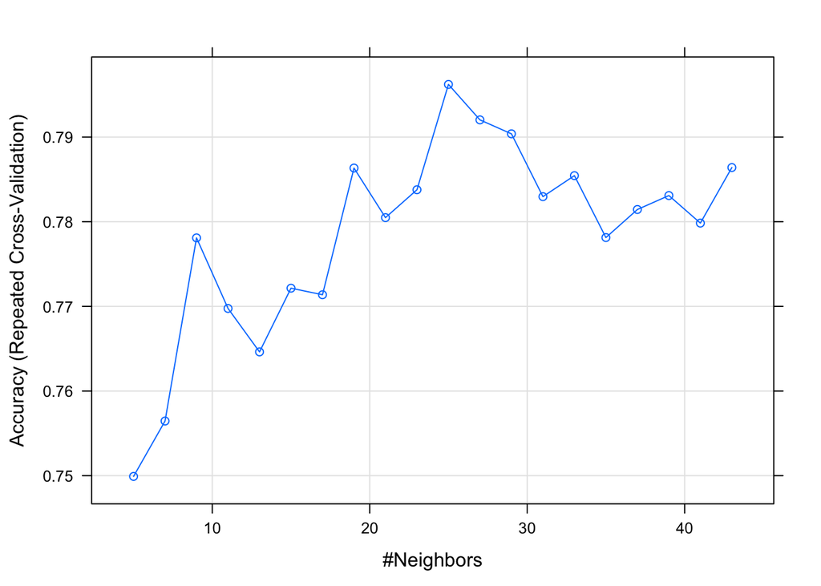

```r
plot(knnFit)
```

```r
df_knn <- knnFit[[4]]
max_Acc <- max(df_knn$Accuracy)
index <- which(df_knn$Accuracy == max_Acc)
k_Acc <- df_knn[index,]$k
unloadPkg(ISLR)
unloadPkg(caret)
```

According the the above we have that the max accuracy is 0.796, which happens when k = 25. I will use this `k` value and reproduce my earlier work.

```r
pima_pred <- knn(train = pima_training, test = pima_test, cl=pima.trainLabels, k=k_Acc)
head(pima_pred)
```

```
## [1] No  No  Yes No  Yes No
## Levels: No Yes
```

```r
IRISPREDCross <- CrossTable(pima.testLabels, pima_pred, prop.chisq = FALSE)
```

```
##
##
##    Cell Contents
## |-------------------------|
## |                       N |
## |           N / Row Total |
## |           N / Col Total |
## |         N / Table Total |
## |-------------------------|
##
##
## Total Observations in Table:  138
##
##
##                 | pima_pred
## pima.testLabels |        No |       Yes | Row Total |
## ----------------|-----------|-----------|-----------|
##              No |        74 |         6 |        80 |
##                 |     0.925 |     0.075 |     0.580 |
##                 |     0.667 |     0.222 |           |
##                 |     0.536 |     0.043 |           |
## ----------------|-----------|-----------|-----------|
##             Yes |        37 |        21 |        58 |
##                 |     0.638 |     0.362 |     0.420 |
##                 |     0.333 |     0.778 |           |
##                 |     0.268 |     0.152 |           |
## ----------------|-----------|-----------|-----------|
##    Column Total |       111 |        27 |       138 |
##                 |     0.804 |     0.196 |           |
## ----------------|-----------|-----------|-----------|
##
##
```

We can also use the method provided to us in class to check what the “best” `k` value would be as well, to double check our above work.

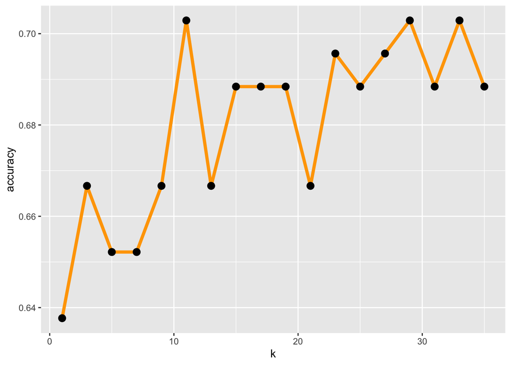

It seems that the method we choose will give us different values for `k` as the “best”. From our plot above using the code from class we get 3 values for the “best” `k`.

```r
index_max <- which(knn_different_k$accuracy == max(knn_different_k$accuracy))
knn_different_k[index_max,] %>%
  kable() %>%
  kable_styling(bootstrap_options = c("striped", "hover"))
```

|  | k | accuracy |
| --- | --- | --- |
| 6 | 11 | 0.703 |
| 15 | 29 | 0.703 |
| 17 | 33 | 0.703 |

We have $k$ = 11, 29, 33. We will use the smallest value, which is $k_{\text{min}}$ = 11. We will repeat the KNN clustering analysis performed above.

```r
k_min <- min(knn_different_k[index_max,]$k)
pima_pred <- knn(train = pima_training, test = pima_test, cl=pima.trainLabels, k=k_min)
head(pima_pred)
```

```
## [1] No  Yes Yes No  Yes No
## Levels: No Yes
```

```r
IRISPREDCross <- CrossTable(pima.testLabels, pima_pred, prop.chisq = FALSE)
```

```
##
##
##    Cell Contents
## |-------------------------|
## |                       N |
## |           N / Row Total |
## |           N / Col Total |
## |         N / Table Total |
## |-------------------------|
##
##
## Total Observations in Table:  138
##
##
##                 | pima_pred
## pima.testLabels |        No |       Yes | Row Total |
## ----------------|-----------|-----------|-----------|
##              No |        74 |         6 |        80 |
##                 |     0.925 |     0.075 |     0.580 |
##                 |     0.679 |     0.207 |           |
##                 |     0.536 |     0.043 |           |
## ----------------|-----------|-----------|-----------|
##             Yes |        35 |        23 |        58 |
##                 |     0.603 |     0.397 |     0.420 |
##                 |     0.321 |     0.793 |           |
##                 |     0.254 |     0.167 |           |
## ----------------|-----------|-----------|-----------|
##    Column Total |       109 |        29 |       138 |
##                 |     0.790 |     0.210 |           |
## ----------------|-----------|-----------|-----------|
##
##
```

We have 3 different k values that were used: $k =$ 3, 11, and 25. I can check the accuracy of these compared with each other.

```r
#k=3
k_3 <- knn(train = pima_training, test = pima_test, cl = pima_train_labs, k=3)
k_3_xtable <- CrossTable(pima_test_labs, k_3, prop.chisq = FALSE)
```

```
##
##
##    Cell Contents
## |-------------------------|
## |                       N |
## |           N / Row Total |
## |           N / Col Total |
## |         N / Table Total |
## |-------------------------|
##
##
## Total Observations in Table:  138
##
##
##                | k_3
## pima_test_labs |        No |       Yes | Row Total |
## ---------------|-----------|-----------|-----------|
##             No |        70 |        10 |        80 |
##                |     0.875 |     0.125 |     0.580 |
##                |     0.660 |     0.312 |           |
##                |     0.507 |     0.072 |           |
## ---------------|-----------|-----------|-----------|
##            Yes |        36 |        22 |        58 |
##                |     0.621 |     0.379 |     0.420 |
##                |     0.340 |     0.688 |           |
##                |     0.261 |     0.159 |           |
## ---------------|-----------|-----------|-----------|
##   Column Total |       106 |        32 |       138 |
##                |     0.768 |     0.232 |           |
## ---------------|-----------|-----------|-----------|
##
##
```

```r
k_3_res <- k_3_xtable$prop.row %>%
  kable(caption = "Results for k = 3") %>%
  kable_styling(bootstrap_options = c("striped", "hover"))
k_3_res
```

Results for k = 3

|  | No | Yes |
| --- | --- | --- |
| No | 0.875 | 0.125 |
| Yes | 0.621 | 0.379 |

```r
# k = k_min
k_min_r <- knn(train = pima_training, test = pima_test, cl = pima_train_labs, k=k_min)
k_min_xtable <- CrossTable(pima_test_labs, k_min_r, prop.chisq = FALSE)
```

```
##
##
##    Cell Contents
## |-------------------------|
## |                       N |
## |           N / Row Total |
## |           N / Col Total |
## |         N / Table Total |
## |-------------------------|
##
##
## Total Observations in Table:  138
##
##
##                | k_min_r
## pima_test_labs |        No |       Yes | Row Total |
## ---------------|-----------|-----------|-----------|
##             No |        74 |         6 |        80 |
##                |     0.925 |     0.075 |     0.580 |
##                |     0.679 |     0.207 |           |
##                |     0.536 |     0.043 |           |
## ---------------|-----------|-----------|-----------|
##            Yes |        35 |        23 |        58 |
##                |     0.603 |     0.397 |     0.420 |
##                |     0.321 |     0.793 |           |
##                |     0.254 |     0.167 |           |
## ---------------|-----------|-----------|-----------|
##   Column Total |       109 |        29 |       138 |
##                |     0.790 |     0.210 |           |
## ---------------|-----------|-----------|-----------|
##
##
```

```r
k_min_res <- k_min_xtable$prop.row %>%
  kable(caption = paste("Results for k = ", k_min)) %>%
  kable_styling(bootstrap_options = c("striped", "hover"))
k_min_res
```

Results for k = 11

|  | No | Yes |
| --- | --- | --- |
| No | 0.925 | 0.075 |
| Yes | 0.603 | 0.397 |

```r
# k = k_Acc
k_Acc_r <- knn(train = pima_training, test = pima_test, cl = pima_train_labs, k=k_Acc)
k_Acc_xtable <- CrossTable(pima_test_labs, k_Acc_r, prop.chisq = FALSE)
```

```
##
##
##    Cell Contents
## |-------------------------|
## |                       N |
## |           N / Row Total |
## |           N / Col Total |
## |         N / Table Total |
## |-------------------------|
##
##
## Total Observations in Table:  138
##
##
##                | k_Acc_r
## pima_test_labs |        No |       Yes | Row Total |
## ---------------|-----------|-----------|-----------|
##             No |        74 |         6 |        80 |
##                |     0.925 |     0.075 |     0.580 |
##                |     0.667 |     0.222 |           |
##                |     0.536 |     0.043 |           |
## ---------------|-----------|-----------|-----------|
##            Yes |        37 |        21 |        58 |
##                |     0.638 |     0.362 |     0.420 |
##                |     0.333 |     0.778 |           |
##                |     0.268 |     0.152 |           |
## ---------------|-----------|-----------|-----------|
##   Column Total |       111 |        27 |       138 |
##                |     0.804 |     0.196 |           |
## ---------------|-----------|-----------|-----------|
##
##
```

```r
k_Acc_res <- k_Acc_xtable$prop.row %>%
  kable(caption = paste("Results for k = ", k_Acc)) %>%
  kable_styling(bootstrap_options = c("striped", "hover"))
k_Acc_res
```

Results for k = 25

|  | No | Yes |
| --- | --- | --- |
| No | 0.925 | 0.075 |
| Yes | 0.638 | 0.362 |

## Logistic Regression and comparison

### Question 6

**Logistic Regression results**  
Compare to the best logistic regression you can get. (Use the full model with all variables, since that is what we have for KNN.) How is the accuracy (assumes the standard cutoff of 0.5) compared to KNN?

#### Creating the logistic regression model

I am going to make a logistic model using all the variables.

```r
pima_logit <- glm(type ~ ., data = pima, binomial(link = "logit"))
summary(pima_logit)
```

```
##
## Call:
## glm(formula = type ~ ., family = binomial(link = "logit"), data = pima)
##
## Deviance Residuals:
##    Min      1Q  Median      3Q     Max
## -3.010  -0.661  -0.369   0.643   2.479
##
## Coefficients:
##             Estimate Std. Error z value Pr(>|z|)
## (Intercept) -9.55465    0.99422   -9.61  < 2e-16 ***
## npreg        0.12252    0.04374    2.80  0.00510 **
## glu          0.03532    0.00424    8.32  < 2e-16 ***
## bp          -0.00770    0.01031   -0.75  0.45560
## skin         0.00677    0.01476    0.46  0.64624
## bmi          0.08268    0.02333    3.54  0.00040 ***
## ped          1.30871    0.36404    3.59  0.00032 ***
## age          0.02637    0.01400    1.88  0.05958 .
## ---
## Signif. codes:  0 '***' 0.001 '**' 0.01 '*' 0.05 '.' 0.1 ' ' 1
##
## (Dispersion parameter for binomial family taken to be 1)
##
##     Null deviance: 676.79  on 531  degrees of freedom
## Residual deviance: 466.32  on 524  degrees of freedom
## AIC: 482.3
##
## Number of Fisher Scoring iterations: 5
```

```r
exp(coef(pima_logit))
```

```
## (Intercept)       npreg         glu          bp        skin         bmi
##    7.09e-05    1.13e+00    1.04e+00    9.92e-01    1.01e+00    1.09e+00
##         ped         age
##    3.70e+00    1.03e+00
```

Not all of the coefficients are statistically significant at the $\alpha$ level of 0.05 in this model, as we can see from the summary above.

```r
coeff_logit <- summary(pima_logit)$coefficients
logit_df <- as.data.frame(coeff_logit)
stat_sig_logit1 <- logit_df[ which(logit_df$"Pr(>|z|)" < 0.001), ]
stat_sig_logit2 <- logit_df[ which(logit_df$"Pr(>|z|)" < 0.01
& logit_df$"Pr(>|z|)" > 0.001), ]
```

The most significant (***) variables are the following,

```r
format(stat_sig_logit1, digits = 5) %>%
  kable() %>%
  kable_styling(bootstrap_options = c("striped", "hover"))
```

|  | Estimate | Std. Error | z value | Pr(>\|z\|) |
| --- | --- | --- | --- | --- |
| (Intercept) | -9.554651 | 0.9942168 | -9.6102 | 7.2388e-22 |
| glu | 0.035321 | 0.0042443 | 8.3220 | 8.6520e-17 |
| bmi | 0.082678 | 0.0233345 | 3.5432 | 3.9533e-04 |
| ped | 1.308708 | 0.3640403 | 3.5950 | 3.2445e-04 |

and then the second most significant (**) variables are the following,

```r
format(stat_sig_logit2, digits = 5) %>%
  kable() %>%
  kable_styling(bootstrap_options = c("striped", "hover"))
```

|  | Estimate | Std. Error | z value | Pr(>\|z\|) |
| --- | --- | --- | --- | --- |
| npreg | 0.12252 | 0.043743 | 2.8008 | 0.0050969 |

We can use the Hosmer and Lemeshow Goodness of Fit test to evaluate logistic regression fit.

```r
loadPkg(ResourceSelection) # function hoslem.test( ) for logit model evaluation
pima_logit_Hoslem <- hoslem.test(pima$type, fitted(pima_logit)) # Hosmer and Lemeshow test, a chi-squared test
unloadPkg(ResourceSelection)
pima_logit_Hoslem
```

```
##
##  Hosmer and Lemeshow goodness of fit (GOF) test
##
## data:  pima$type, fitted(pima_logit)
## X-squared = 532, df = 8, p-value <2e-16
```

The Hosmer-Lemeshow statistic indicates a poor fit if the significance value is less than 0.05. The p-value of 0 is below 0.05 which indicates the model is not really a good fit, despite the fact that several of the coefficients are significant.

Receiver-Operator-Characteristic (ROC) curve and Area-Under-Curve (AUC) measures the true positive rate (or sensitivity) against the false positive rate (or specificity). The area-under-curve is always between 0.5 and 1. Values higher than 0.8 is considered good model fit.

```r
loadPkg(pROC) # receiver operating characteristic curve, gives the diagnostic ability of a binary classifier system as its discrimination threshold is varied. The curve is on sensitivity/recall/true-positive-rate vs false_alarm/false-positive-rate/fall-out.
pima_prob <- predict(pima_logit, type = c("response"))
pima$prob <- pima_prob
h_pima <- roc(type~prob, data=pima)
auc(h_pima) # area-under-curve prefer 0.8 or higher.
```

```
## Area under the curve: 0.86
```

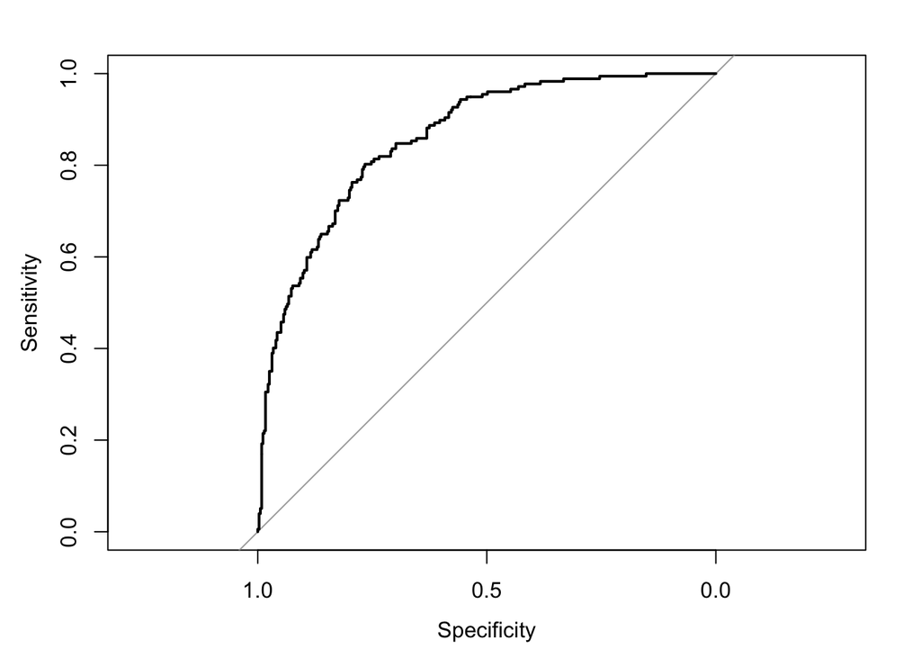

```r
plot(h_pima)
```

We have here the area-under-curve of 0.86, which is better than 0.8, and is considered a good model.

McFadden is another evaluation tool we can use on logit regressions. This is part of what is called pseudo-R-squared values for evaluation tests. We can calculate McFadden statistics for our model.

```r
loadPkg(pscl) # use pR2( ) function to calculate McFadden statistics for model eval
pima_logit_2pr2 <- pR2(pima_logit)
```

```
## fitting null model for pseudo-r2
```

```r
pima_logit_2pr2
```

```
##      llh  llhNull       G2 McFadden     r2ML     r2CU
## -233.161 -338.394  210.466    0.311    0.327    0.454
```

```r
unloadPkg(pscl)
```

With the McFadden value of 0.311, which is analgous to the coefficient of determination $R^2$, only about 31% of the variations in y is explained by the explanatory variables in the model.

#### Comparing to KNN results

Now we can look at the accuracy and the confusion matrix of our logit model.

```r
loadPkg(regclass)
pima_logit_confusion = confusion_matrix(pima_logit)
unloadPkg(regclass)
```

```r
xkabledply(pima_logit_confusion,"Confusion Matrix: Logit model 2, cutoff = 0.5")
```

Confusion Matrix: Logit model 2, cutoff = 0.5

|  | Predicted No | Predicted Yes | Total |
| --- | --- | --- | --- |
| Actual No | 317 | 38 | 355 |
| Actual Yes | 75 | 102 | 177 |
| Total | 392 | 140 | 532 |

```r
row_names <- c("Predicted No", "Predicted Yes")
row_1 <- c(pima_logit_confusion[1]/pima_logit_confusion[3], pima_logit_confusion[2]/pima_logit_confusion[3])
row_2 <- c(pima_logit_confusion[4]/pima_logit_confusion[6], pima_logit_confusion[5]/pima_logit_confusion[6])
dec_vals <- rbind(row_1, row_2)
dec_vals <- as.data.frame(dec_vals)
names(dec_vals) <- row_names
row.names(dec_vals) <- c("Actual No", "Actual Yes")
dec_vals %>%
  kable(caption = "Accuracy of logit model") %>%
  kable_styling(bootstrap_options = c("striped", "hover"))
```

Accuracy of logit model

[output not shown]

```r
true_no <- 100*dec_vals[1,1]
fake_no <- 100*dec_vals[1,2]
true_yes <- 100*dec_vals[2,2]
fake_yes <- 100*dec_vals[2,1]
```

[output not shown]

It seems the accuracy of these two models are flipped. The KNN is better at predicting the `No`s, and the logit model is better at predicted the `Yes`s.